# Introduction to Spatial Analysis in R

We begin by loading packages. You must have recent versions of R, as well as recent versions of the `sf` and `ggplot2` packages. If you are unsure, please update! This tutorial is largely based on the `sf` package which, in my opinion, will be the primary spatial package in the forseeable future. For more on spatial packages in R, see this [r-bloggers](https://www.r-bloggers.com/should-i-learn-sf-or-sp-for-spatial-r-programming/) article.

If you want to follow along using a local file, you can download either a [`.R`](https://github.com/remi-daigle/Spatial_Intro/raw/master/index.R) script or a [`.Rmd`](https://github.com/remi-daigle/Spatial_Intro/raw/master/index.Rmd) version of this tutorial

```r
require(robis)
require(sf)
require(rnaturalearth)
require(tidyverse)
require(marmap)
require(sdmpredictors)
```

# Study Area

The first thing I like to do whenever doing anything spatial in R is to prepare for basic mapping.

1. Define the extent of the study area
2. Define projection(s) to use in this study (see [projection wizard](http://projectionwizard.org/))
3. Create a bounding box
4. Download a basemap and crop it

```r
# define projections
longLatProj <- "+proj=longlat +ellps=GRS80 +datum=NAD83 +no_defs"
utmProj <- "+proj=utm +zone=19 +ellps=GRS80 +datum=NAD83 +units=m +no_defs"

# study area extent
latTop <- 50.5
latBottom <- 49
longLeft <- -67.5
longRight <- -65.5

# create bounding box
septiles_bbox <- rbind(c(longLeft,latBottom),
                       c(longLeft,latTop),
                       c(longRight,latTop),
                       c(longRight,latBottom),
                       c(longLeft,latBottom)) %>%
  list() %>%
  st_polygon() %>%
  st_sfc(crs=longLatProj) %>%
  st_transform(utmProj)

# get a basemap and crop to bbox (with 20km buffer)
septiles <- ne_countries(scale = 10, country = "Canada") %>%
  st_as_sf() %>%
  st_transform(utmProj) %>%
  st_intersection(st_buffer(septiles_bbox,20000))
```

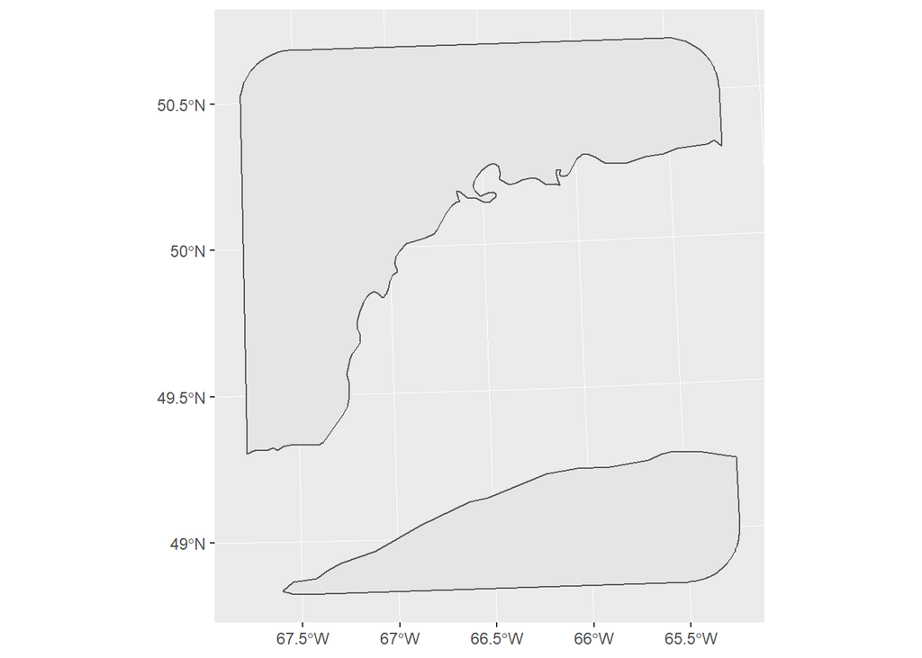

```r
# plot it
ggplot(septiles)+
  geom_sf()
```

Those rounded edges look a little silly, so let’s plot a better map with the limits to our study extent.

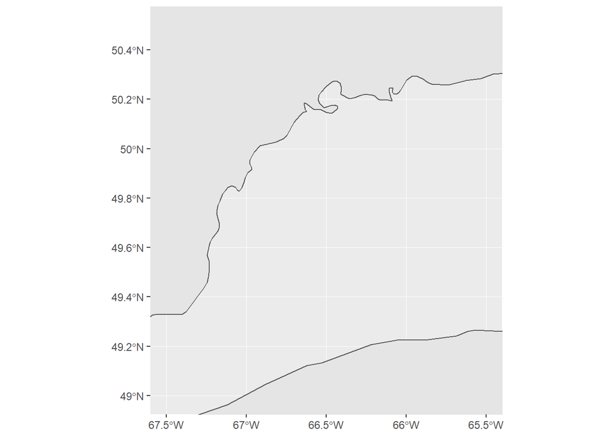

```r
ggplot(septiles)+
  geom_sf()+
  coord_sf(crs=longLatProj,
           xlim = c(longRight,longLeft),
           ylim = c(latTop,latBottom))
```

# Biological Data

You can download species presence data from [OBIS](http://iobis.org/) using the `robis` package.

I added the `, year=1991` argument to hammering the conference venue internet. Feel free to remove that if you’re at home!

```r
obis <- occurrence(geometry = st_as_text(st_transform(septiles_bbox,longLatProj)), year=1991) %>%
  st_as_sf(coords = c("decimalLongitude", "decimalLatitude"),
           crs=longLatProj) %>%
  st_transform(utmProj)
```

```
##
Retrieved 306 records of 306 (100%)
```

```r
# head(obis)
```

Using this data we can plot the 6 most abundant species (or anything else we wanted really…).

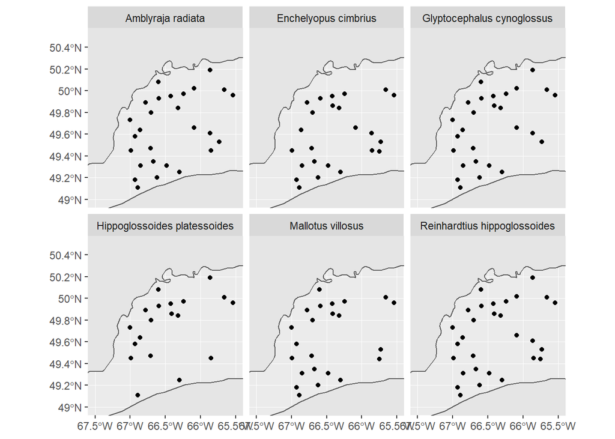

```r
obis_top6 <- table(obis$species) %>%
  sort(decreasing = TRUE) %>%
  as.data.frame() %>%
  head(6)


ggplot(septiles)+
  geom_sf()+
  geom_sf(data=filter(obis,species %in% obis_top6$Var1))+
  facet_wrap(~species)+
  coord_sf(crs=longLatProj,
           xlim = c(longRight,longLeft),
           ylim = c(latTop,latBottom))
```

# Physical data

We can get bathymetric data from NOAA using the `marmap` package (amongst others). You would usually use this as raster data, but since we need spatial point data later, I will convert this right away.

```r
bathy <- getNOAA.bathy(longLeft,longRight,latTop,latBottom,resolution=1,keep = TRUE) %>%
  marmap::as.xyz() %>%
  st_as_sf(coords = c("V1", "V2"), remove = FALSE, crs = longLatProj, agr = "constant") %>%
  st_transform(utmProj) %>%
  rename("longitude"="V1",
         "latitude"="V2",
         "depth"="V3")
```

```
## File already exists ; loading 'marmap_coord_-67.5;49;-65.5;50.5_res_1.csv'
```

We can now plot the bathymetric data (yes, that’s points, just close together)

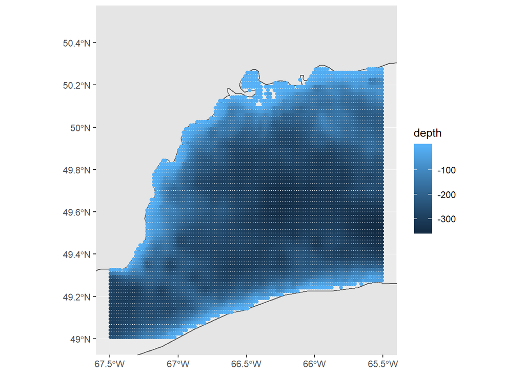

```r
ggplot(septiles)+
  geom_sf()+
  geom_sf(data=bathy %>% filter(depth<0),aes(col=depth))+
  coord_sf(crs=longLatProj,
           xlim = c(longRight,longLeft),
           ylim = c(latTop,latBottom))
```

The `sdmpredictors` package is a great source for a multitude of environmental factors (pH, Salinity, SST, Chlorophyll, sea ice, etc). It’s a super convenient interface to the following databases:

- WorldClim: Hijmans, R.J., S.E. Cameron, J.L. Parra, P.G. Jones and A. Jarvis, 2005. Very high resolution interpolated climate surfaces for global land areas. International Journal of Climatology 25: 1965-1978. (http://dx.doi.org/10.1002/joc.1276)
- ENVIREM: Title, P. O. and Bemmels, J. B. 2017. envirem: An expanded set of bioclimatic and topographic variables increases flexibility and improves performance of ecological niche modeling. Ecography (Cop.). in press. (http://doi.wiley.com/10.1111/ecog.02880)

-Bio-ORACLE: Tyberghein L., Verbruggen H., Pauly K., Troupin C., Mineur F. & De Clerck O. Bio-ORACLE: a global environmental dataset for marine species distribution modeling. Global Ecology and Biogeography (http://dx.doi.org/10.1111/j.1466-8238.2011.00656.x).

- MARSPEC: Sbrocco, EJ and Barber, PH (2013) MARSPEC: Ocean climate layers for marine spatial ecology. Ecology 94: 979.(http://dx.doi.org/10.1890/12-1358.1)

Let’s download a few layers and crop them to our study area.

```r
datasets <- list_datasets(terrestrial = FALSE, marine = TRUE)
layers <- list_layers(datasets)

enviro <- load_layers(layers[layers$name %in% c("pH",
                                                "Salinity",
                                                "Sea surface temperature (mean)",
                                                "Chlorophyll concentration (mean at min depth)",
                                                "Sea ice thickness (maximum)") &
                               layers$dataset_code == "Bio-ORACLE",], datadir = getwd())

enviro <- enviro %>%
  mask(as(st_transform(septiles_bbox,projection(enviro)),"Spatial")) %>%
  rasterToPoints(spatial = TRUE) %>%
  st_as_sf(coords = c("enviro", "y"), remove = FALSE, crs = longLatProj, agr = "constant") %>%
  st_transform(utmProj)
```

plots!

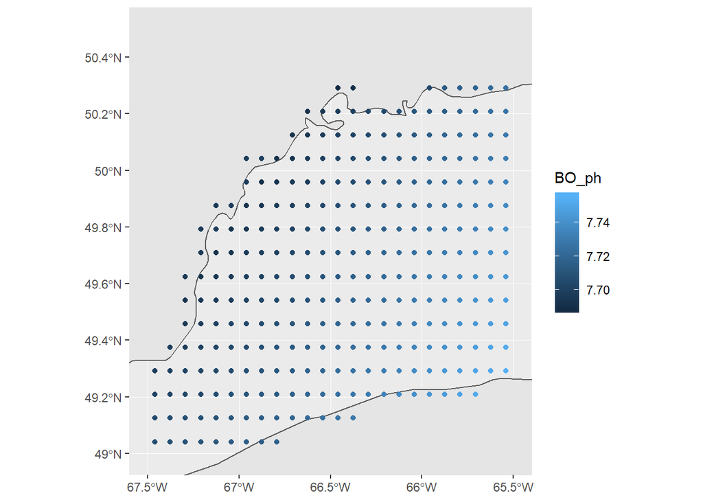

```r
ggplot(septiles)+
  geom_sf()+
  geom_sf(data=enviro,aes(col=BO_ph))+
  coord_sf(crs=longLatProj,
           xlim = c(longRight,longLeft),
           ylim = c(latTop,latBottom))
```

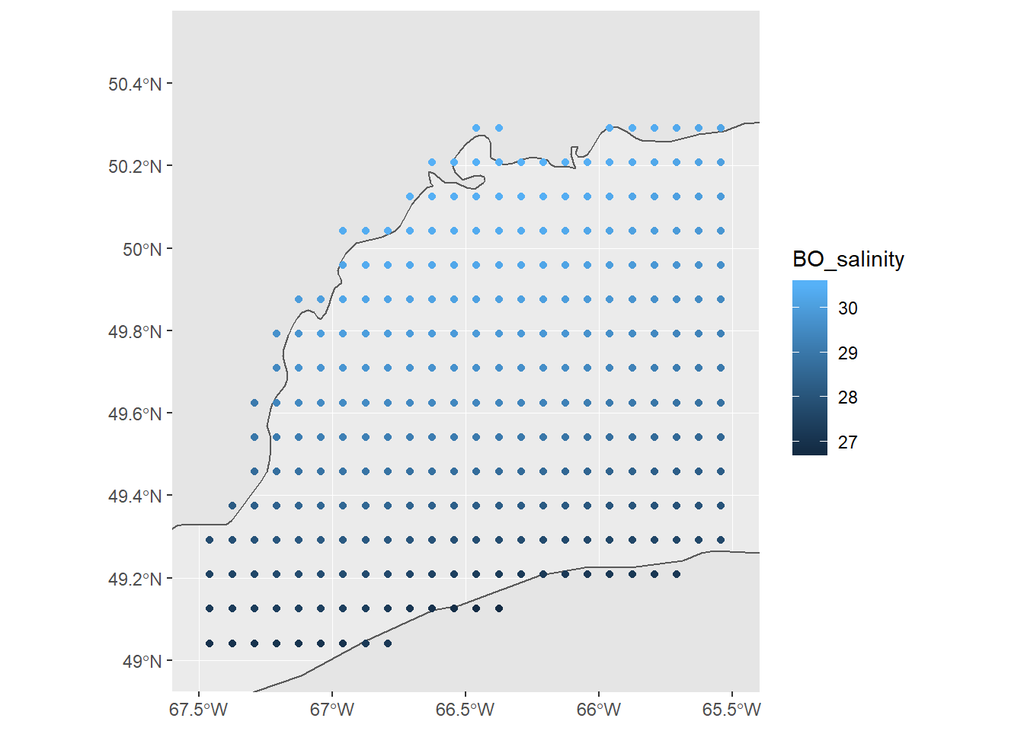

```r
ggplot(septiles)+
  geom_sf()+
  geom_sf(data=enviro,aes(col=BO_salinity))+
  coord_sf(crs=longLatProj,
           xlim = c(longRight,longLeft),
           ylim = c(latTop,latBottom))
```

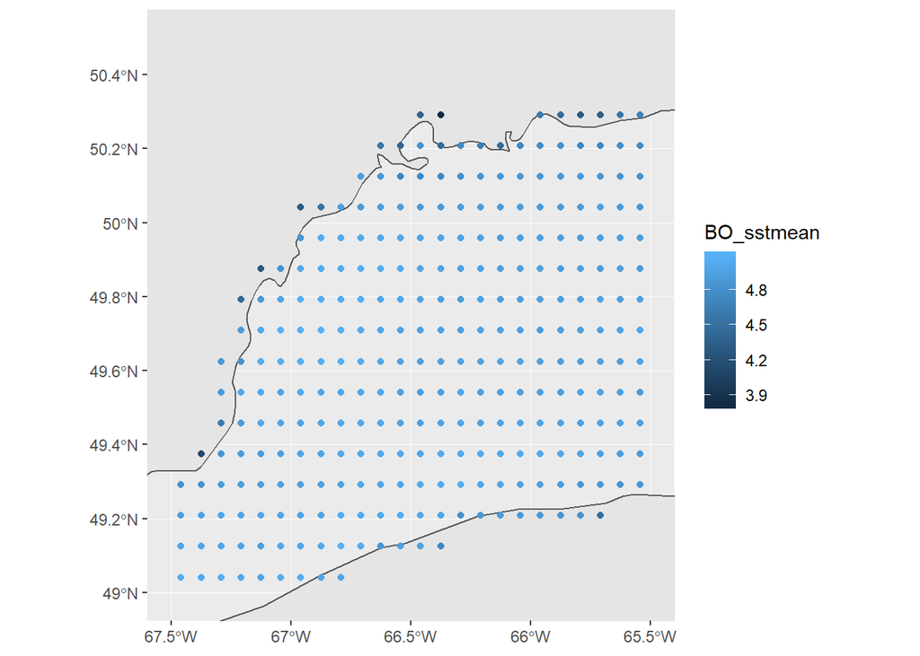

```r
ggplot(septiles)+
  geom_sf()+
  geom_sf(data=enviro,aes(col=BO_sstmean))+
  coord_sf(crs=longLatProj,
           xlim = c(longRight,longLeft),
           ylim = c(latTop,latBottom))
```

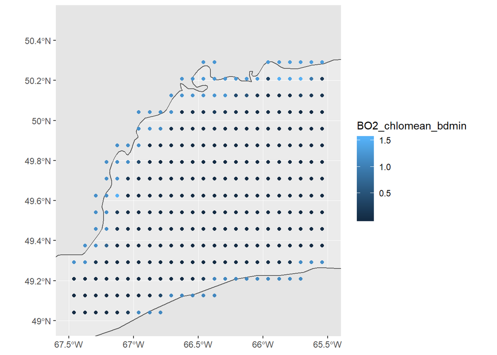

```r
ggplot(septiles)+
  geom_sf()+
  geom_sf(data=enviro,aes(col=BO2_chlomean_bdmin))+
  coord_sf(crs=longLatProj,
           xlim = c(longRight,longLeft),
           ylim = c(latTop,latBottom))
```

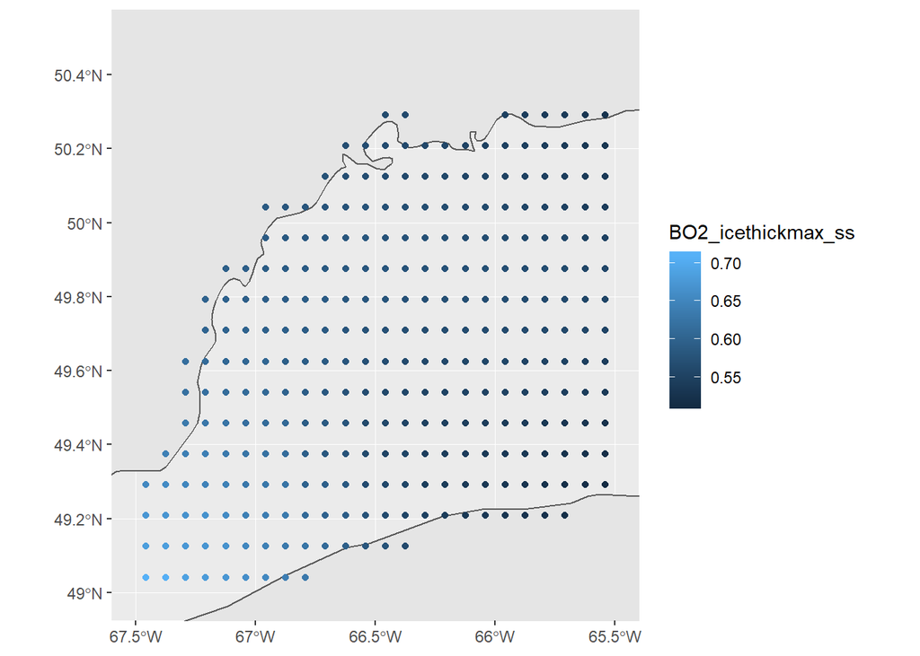

```r
ggplot(septiles)+
  geom_sf()+
  geom_sf(data=enviro,aes(col=BO2_icethickmax_ss))+
  coord_sf(crs=longLatProj,
           xlim = c(longRight,longLeft),
           ylim = c(latTop,latBottom))
```

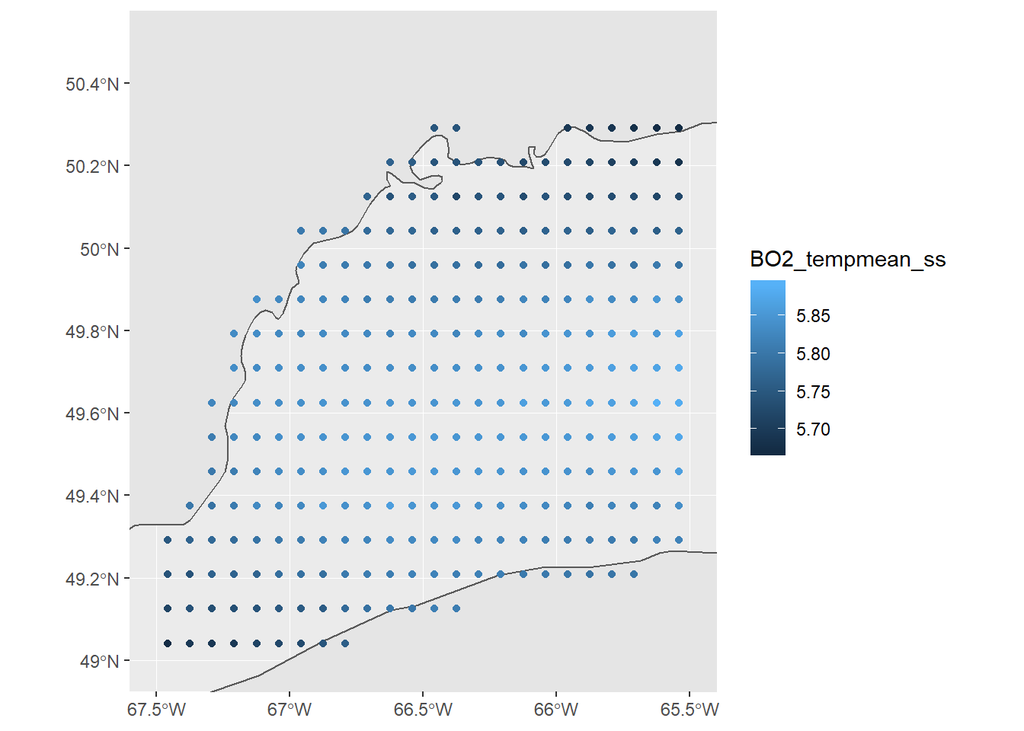

```r
ggplot(septiles)+
  geom_sf()+
  geom_sf(data=enviro,aes(col=BO2_tempmean_ss))+
  coord_sf(crs=longLatProj,
           xlim = c(longRight,longLeft),
           ylim = c(latTop,latBottom))
```

# Cleaning up for analysis of spatial points

Extract all `sf` points coordinates in regular numerical columns as utm coordinates and clean up the data so we just have cod, salinity and temperature.

```r
obis$utm_x <- st_coordinates(obis)[,1]
obis$utm_y <- st_coordinates(obis)[,2]
bathy$utm_x <- st_coordinates(bathy)[,1]
bathy$utm_y <- st_coordinates(bathy)[,2]
enviro$utm_x <- st_coordinates(enviro)[,1]
enviro$utm_y <- st_coordinates(enviro)[,2]


cod <- obis %>%
  as.data.frame() %>%
  filter(species=="Gadus morhua") %>%
  dplyr::select("individualCount","utm_x","utm_y") %>%
  mutate(individualCount = if_else(is.na(individualCount),1,individualCount)) %>%  #assume NA = 1
  group_by(utm_x,utm_y) %>%
  summarize(individualCount = sum(individualCount)) %>%
  ungroup()

write_csv(cod,"cod.csv")


salinity <- enviro %>%
  as.data.frame() %>%
  dplyr::select("BO_salinity","utm_x","utm_y")

write_csv(salinity,"salinity.csv")

sst <- enviro %>%
  as.data.frame() %>%
  dplyr::select("BO_sstmean","utm_x","utm_y")

write_csv(sst,"sst.csv")
```

# Files for day 2 with Marie-Josee

Download zipped folder [here](https://github.com/remi-daigle/Spatial_Intro/raw/master/filesforspatialstats_MarieJosee.zip)